# pop

Rikiya Honda

# 手順1: import data

```r
# url for csv. file
url <- "https://raw.githubusercontent.com/Ricky-s-a/R_tutoring/main/Data/pop.csv"

# import data
pop <- read.csv(url)

# check
head(pop)
```

```
##   year number
## 1 2000 126926
## 2 2001 127316
## 3 2002 127486
## 4 2003 127694
## 5 2004 127787
## 6 2005 127768
```

# 手順2: modeling

```r
# define the linear model
pop.lm <- lm(number ~ year, data = pop)
```

# 手順3: visualization

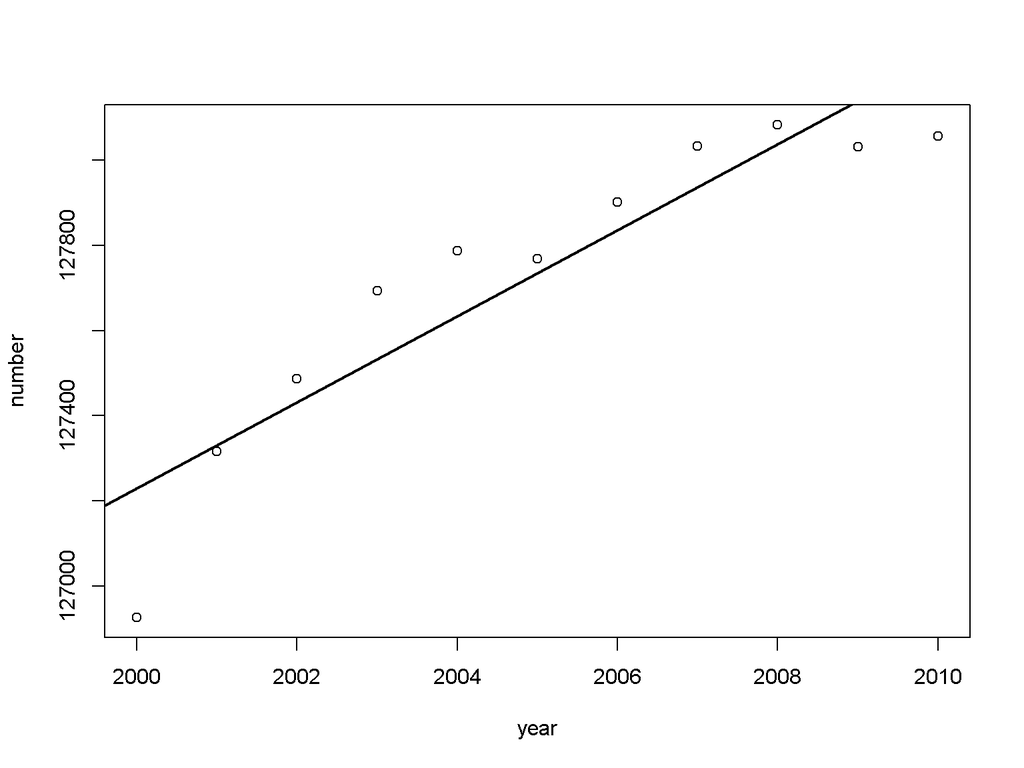

```r
# visualize
plot(pop)
abline(pop.lm, lwd = 2)
```

```r
# coefficients
coefficients(pop.lm)
```

```
## (Intercept)        year
## -74678.9545    100.9545
```

```r
# correlation
cor(pop$year, pop$number)
```

```
## [1] 0.9189531
```

相関係数について説明を加えると、一般的に相関係数の絶対値が0.3を下回ると関係性が弱いとされ、0.3から0.6の間は中程度の関係性があるといわれ、相関係数の絶対値が0.6以上の場合、強い相関があるといわれる。今回は、相関係数が$0.9189531$であり、かなり強い正の相関が観察される。

# 手順4: parameter estimation

以下ではモデルの予測値を確認する。

```r
# まず年を`2005`年に設定する
year <- 2005

# estimate the data for the year 2005
-74678.9545 + 100.9545 * year
```

```
## [1] 127734.8
```

この結果を実際の2005年の値と比べてみると、$127768 - 127734.8 = 33.2$となり、2005年におけるモデルの精度は比較的高いのではないかと予測される。

```r
# the real value
pop[pop$year == 2005,2]
```

```
## [1] 127768
```

# 手順5: data summarization

```r
# summary
summary(pop.lm)
```

```
##
## Call:
## lm(formula = number ~ year, data = pop)
##
## Residuals:
##     Min      1Q  Median      3Q     Max
## -304.14  -60.91   46.23   80.66  161.00
##
## Coefficients:
##              Estimate Std. Error t value Pr(>|t|)
## (Intercept) -74678.95   28955.20  -2.579   0.0297 *
## year           100.95      14.44   6.991 6.39e-05 ***
## ---
## Signif. codes:  0 '***' 0.001 '**' 0.01 '*' 0.05 '.' 0.1 ' ' 1
##
## Residual standard error: 151.5 on 9 degrees of freedom
## Multiple R-squared:  0.8445, Adjusted R-squared:  0.8272
## F-statistic: 48.87 on 1 and 9 DF,  p-value: 6.391e-05
```

```r
# set variables
pop$pre <- predict(pop.lm)
pop$res <- residuals(pop.lm)

# check
head(pop)
```

```
##   year number      pre        res
## 1 2000 126926 127230.1 -304.13636
## 2 2001 127316 127331.1  -15.09091
## 3 2002 127486 127432.0   53.95455
## 4 2003 127694 127533.0  161.00000
## 5 2004 127787 127634.0  153.04545
## 6 2005 127768 127734.9   33.09091
```

# APPENDIX

## the equaltion

### true model

`number`と`year`を二つの変数としてとらえ、直線の関係で表すと以下のようになる。直線で`number`と`year`を説明した場合、説明できない部分が生じる。その値がresiduals（残渣）である。

$$Number = \beta_1 + \beta_2Year + residuals$$

### estimated model

推計されたモデルは以下のようになる。残渣が0になるように$\hat \beta_1$と$\hat \beta_2$が決められるため、残渣の項は式に含まれない。ここで注意しなければならないことは、上の式に書かれている$Number$と下の式で書かれている$\hat Number$は違う点である。このように変数に(hat)$\hat x$をつけると、その変数は推定された値であることを示している。ここでは、$Number$は実際の人口数を示しているのに対し、$\hat Number$は予測された値であり、実際の値$Number$とは違う点に気を付けてほしい。

$$\hat Number = \hat \beta_1 + \hat \beta_2Year$$

### residuals

残渣(residuals)は、実際の値と予測値の差分で計算される。今回の場合だと、実際の人口数である$Number$と線形モデルによって推計された値である$\hat Number$の差分がそれぞれの年の残渣の値になる。

$$residuals = Number - \hat Number$$

以下ではイメージを作るため、実際の値を青で、予測値を赤で示すことによって、実際の値と予測値の差を示そうとしている。

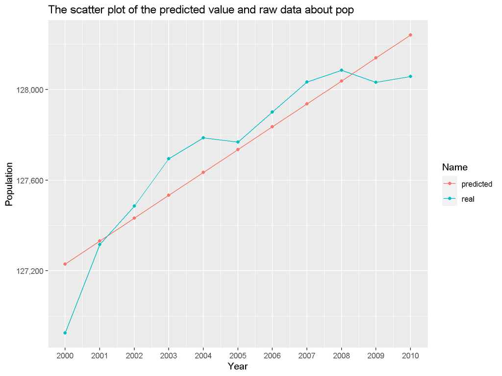

```r
# load packages
library(tidyverse)
library(modelr)
library(scales)

# define the data for visualization
pop_plot <- pop %>%
  `names<-`(value = c("year", "real", "predicted", "residual")) %>%
  pivot_longer(cols = c(-year))

# raw v.s. expected value
pop_plot %>%
  filter(name != "residual") %>%
  ggplot(aes(year, value, color = name)) +
  geom_line() +
  geom_point() +
  scale_x_continuous(breaks = seq(2000, 2010, by = 1)) +
  scale_y_continuous(labels = comma) +
  labs(title = "The scatter plot of the predicted value and raw data about pop",
       x = "Year",
       y = "Population",
       color = "Name")
```

残渣のみを記述したのが以下のグラフである。横軸０は、残渣が０、つまり予測値と実際の値が同じ$(residuals = Number - \hat Number = 0)$であり、モデルの説明力が高いことを示している。一方、横軸の値が0から離れると、推計したモデルの説明力が低くなることを示している。2000年の残渣は、約-300、つまり、予測値と実際の値が-300外れており、実際の値よりも、予測値のほうが大きかったこと示している。
$$Number - \hat Number < 0 \\
Number < \hat Number$$

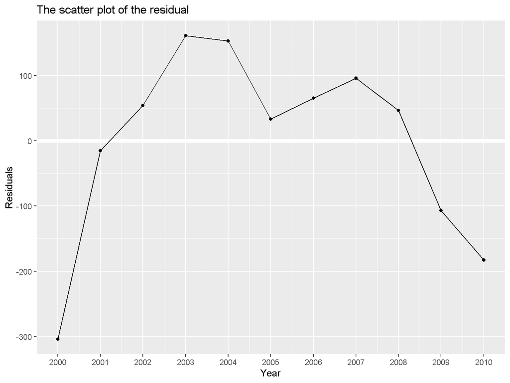

```r
# residual
pop %>%
  ggplot(aes(year, res)) +
  geom_ref_line(h = 0) +
  geom_point() +
  geom_line() +
  scale_x_continuous(breaks = seq(2000, 2010, by = 1)) +
  labs(title = "The scatter plot of the residual",
       x = "Year",
       y = "Residuals")
```